# Choosing and comparing aggregation sequences

```r
library(HydroBOT)
library(dplyr)
library(ggplot2)
```

The choices of aggregation sequences are extremely important, and have large bearing on the final outcomes. They should be chosen to reflect the underlying processes, address the questions of an analysis, and be mathematically defensible. This is not always easy, but at the very least, significant thought and justification should go into them.

Briefly, we illustrate the outcome of some simple aggregation functions built into HydroBOT, accentuating their different mathematical properties, though in general they should be chosen based on how well those properties match the processes underlying the aggregation step (e.g. how to birds combine over space, or how do life stages combine into species performance).

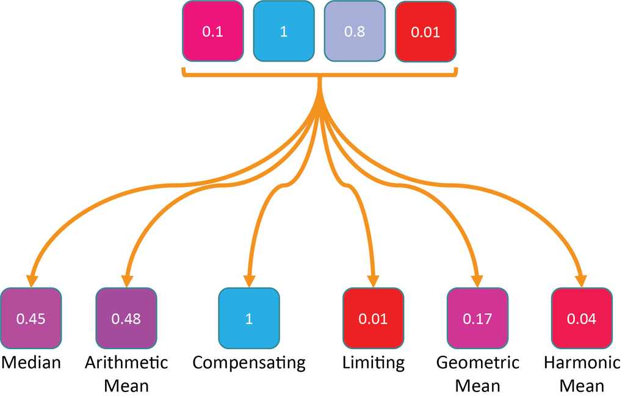

Illustration of a small set of four values (top boxes). Each of the bottom boxes is the single aggregated value according to the function labeled below. We do not include zero in the set of top values, as a single zero forces the Geometric and Harmonic means to equal zero due to their multiplicative nature.

## Comparing aggregation sequences

Given the importance of aggregations, HydroBOT can be used to compare different aggregation sequences to better understand and visualise their implications for the outcomes. Here, we demonstrate a simple example of three potential aggregation pathways.

### Setup

We keep the full workflow in-memory, since this is a small run.

```r
ewr_out <- prep_run_save_ewrs(
  hydro_dir = system.file("extdata/testsmall/hydrographs", package = "HydroBOT"),
  output_parent_dir = "test_dir",
  outputType = list("none"),
  returnType = list("yearly")
)
```

We’ll use a simplified set of aggregations, over time, into small-scale ‘env_obj’ theme scales, then sdl units, and to Target theme levels.

```r
aggseq <- list(
  all_time = "all_time",
  env_obj = c("ewr_code_timing", "env_obj"),
  sdl_units = sdl_units,
  Target = c("env_obj", "Target")
)
```

We create a modified geometric mean because of all the zeros in the data.

```r
geomeanplus <- function(x) {
  add_eps <- min(x[x > 0],
    na.rm = TRUE
  ) / 10
  x[x == 0] <- add_eps
  GeometricMean(x)
}
```

```r
funseq_compare <- list(
  "ArithmeticMean",
  "ArithmeticMean",
  c("ArithmeticMean", "Median", "geomeanplus"),
  "ArithmeticMean"
)
```

The warning here are because when a set of values are *all* NA, there’s nothing the na.rm setting can do.

```r
aggout_compare <- read_and_agg(
  datpath = ewr_out,
  type = "achievement",
  geopath = bom_basin_gauges,
  causalpath = causal_ewr,
  groupers = "scenario",
  aggCols = "ewr_achieved",
  auto_ewr_PU = TRUE,
  aggsequence = aggseq,
  funsequence = funseq_compare,
  saveintermediate = TRUE,
  namehistory = FALSE,
  keepAllPolys = FALSE,
  returnList = TRUE,
  add_max = FALSE,
  savepath = NULL
)
```

```
Warning: There were 17 warnings in `dplyr::summarise()`.
The first warning was:
ℹ In argument: `dplyr::across(...)`.
ℹ In group 107: `scenario = "base"`, `env_obj = "NV4b"`, `polyID =
  "r6367k2uy6m"`.
Caused by warning in `min()`:
! no non-missing arguments to min; returning Inf
ℹ Run `dplyr::last_dplyr_warnings()` to see the 16 remaining warnings.
```

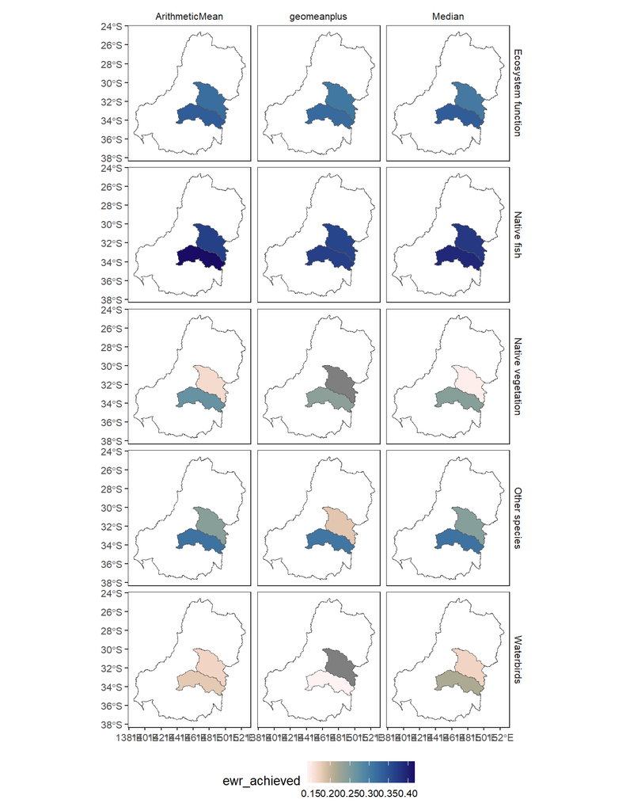

```r
aggout_compare$Target |>
  dplyr::filter(scenario == "base") |> # Just look at one scenario
  plot_outcomes(
    outcome_col = "ewr_achieved",
    plot_type = "map",
    colorset = "ewr_achieved",
    pal_list = list("scico::lapaz"),
    pal_direction = -1,
    facet_col = "aggfun_3",
    facet_row = "Target",
    underlay_list = "basin"
  ) +
  ggplot2::theme(legend.position = "bottom")
```

We could extend the above approach to multiple steps, but it soon gets factorially complicated. If we want to compare different aggregation sequences, it is often easiest to specify them separately. Here, we compare the same three aggregation functions as above, but carried through each stage.

```r
meanseq <- list(
  "ArithmeticMean",
  "ArithmeticMean",
  "ArithmeticMean",
  "ArithmeticMean"
)

medseq <- list(
  "Median",
  "Median",
  "Median",
  "Median"
)

geoseq <- list(
  "geomeanplus",
  "geomeanplus",
  "geomeanplus",
  "geomeanplus"
)
```

Run each of those separately through the aggregator

```r
aggout_mean <- read_and_agg(
  datpath = ewr_out,
  type = "achievement",
  geopath = bom_basin_gauges,
  causalpath = causal_ewr,
  groupers = "scenario",
  aggCols = "ewr_achieved",
  auto_ewr_PU = TRUE,
  aggsequence = aggseq,
  funsequence = meanseq,
  saveintermediate = TRUE,
  namehistory = FALSE,
  keepAllPolys = FALSE,
  returnList = TRUE,
  add_max = FALSE,
  savepath = NULL
)

aggout_med <- read_and_agg(
  datpath = ewr_out,
  type = "achievement",
  geopath = bom_basin_gauges,
  causalpath = causal_ewr,
  groupers = "scenario",
  aggCols = "ewr_achieved",
  auto_ewr_PU = TRUE,
  aggsequence = aggseq,
  funsequence = medseq,
  saveintermediate = TRUE,
  namehistory = FALSE,
  keepAllPolys = FALSE,
  returnList = TRUE,
  add_max = FALSE,
  savepath = NULL
)

aggout_geo <- read_and_agg(
  datpath = ewr_out,
  type = "achievement",
  geopath = bom_basin_gauges,
  causalpath = causal_ewr,
  groupers = "scenario",
  aggCols = "ewr_achieved",
  auto_ewr_PU = TRUE,
  aggsequence = aggseq,
  funsequence = geoseq,
  saveintermediate = TRUE,
  namehistory = FALSE,
  keepAllPolys = FALSE,
  returnList = TRUE,
  add_max = FALSE,
  savepath = NULL
)
```

For the first step (over time), we’ll bind and make one plot call.

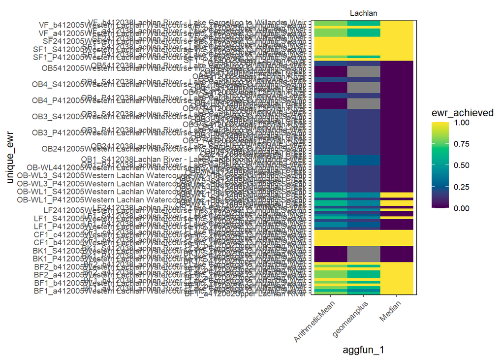

```r
aggout_mean$all_time |>
  bind_rows(aggout_med$all_time) |>
  bind_rows(aggout_geo$all_time) |>
  dplyr::filter(scenario == "base" & SWSDLName == "Lachlan") |>
  dplyr::mutate(unique_ewr = paste0(ewr_code_timing, gauge, planning_unit_name)) |>
  # clean names
  plot_outcomes(
    outcome_col = "ewr_achieved",
    y_col = "unique_ewr",
    x_col = "aggfun_1",
    plot_type = "heatmap",
    colorset = "ewr_achieved",
    pal_list = "grDevices::Viridis",
    facet_col = "SWSDLName"
  ) +
  theme(axis.text.x = element_text(angle = 45, hjust = 1))
```

For the second step (env_obj)

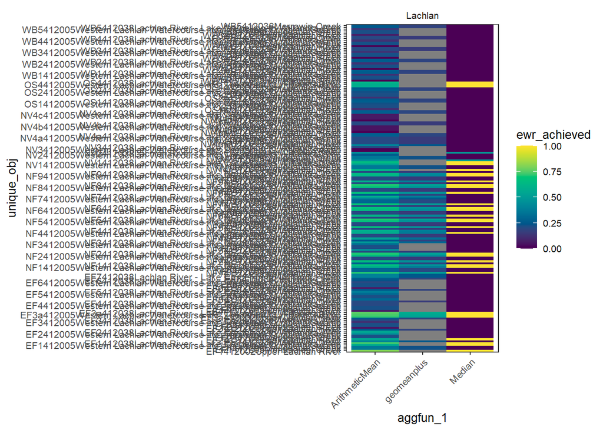

```r
aggout_mean$env_obj |>
  bind_rows(aggout_med$env_obj) |>
  bind_rows(aggout_geo$env_obj) |>
  dplyr::filter(scenario == "base" & SWSDLName == "Lachlan") |>
  dplyr::mutate(unique_obj = paste0(env_obj, gauge, planning_unit_name)) |>
  # clean names
  plot_outcomes(
    outcome_col = "ewr_achieved",
    y_col = "unique_obj",
    x_col = "aggfun_1",
    plot_type = "heatmap",
    colorset = "ewr_achieved",
    pal_list = "grDevices::Viridis",
    facet_col = "SWSDLName"
  ) +
  theme(axis.text.x = element_text(angle = 45, hjust = 1))
```

That is a bit weird, because what we really want to do is combine those env_objs across gauges. Which is exactly what step three does:

For the third step (space)

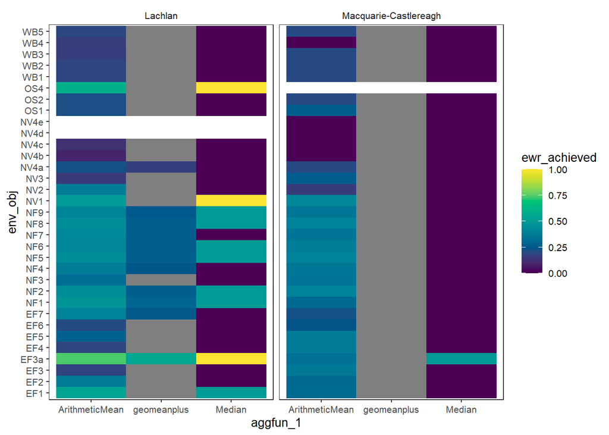

```r
aggout_mean$sdl_units |>
  bind_rows(aggout_med$sdl_units) |>
  bind_rows(aggout_geo$sdl_units) |>
  dplyr::filter(scenario == "base") |>
  # clean names
  plot_outcomes(
    outcome_col = "ewr_achieved",
    y_col = "env_obj",
    x_col = "aggfun_1",
    plot_type = "heatmap",
    colorset = "ewr_achieved",
    pal_list = "grDevices::Viridis",
    facet_col = "SWSDLName"
  )
```

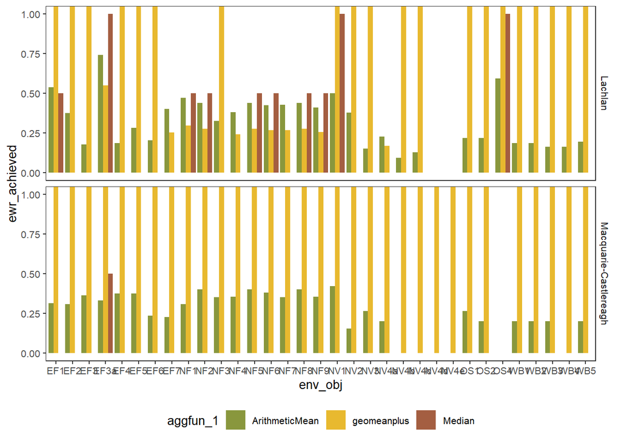

```r
aggout_mean$sdl_units |>
  bind_rows(aggout_med$sdl_units) |>
  bind_rows(aggout_geo$sdl_units) |>
  dplyr::filter(scenario == "base") |>
  # clean names
  plot_outcomes(
    outcome_col = "ewr_achieved",
    x_col = "env_obj",
    colorset = "aggfun_1",
    pal_list = "ltc::trio2",
    facet_row = "SWSDLName",
    position = "dodge"
  ) +
  theme(legend.position = "bottom")
```

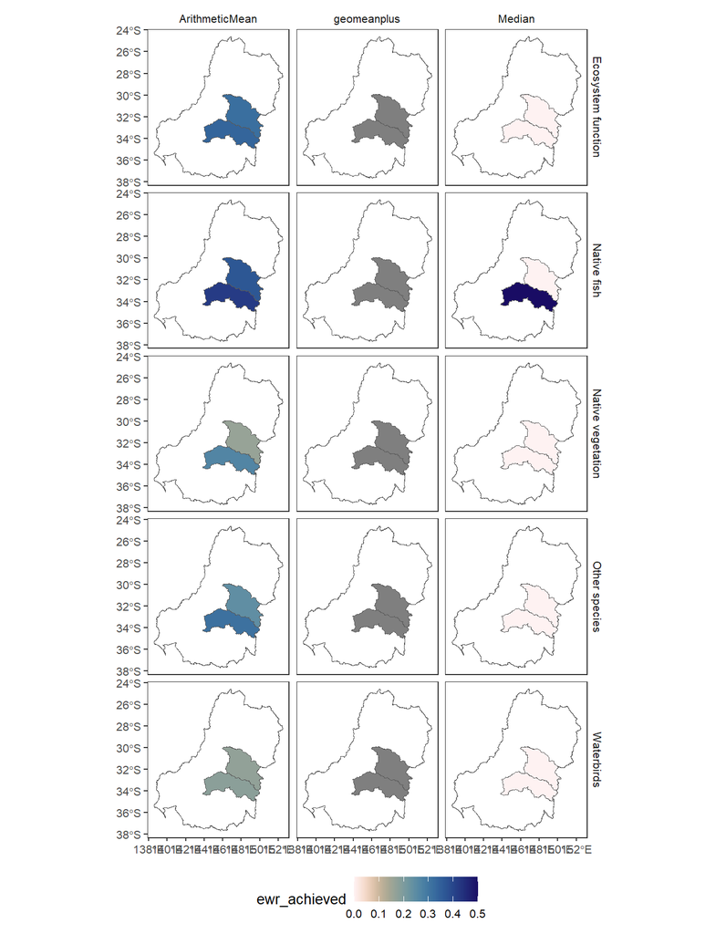

```r
aggout_mean$Target |>
  bind_rows(aggout_med$Target) |>
  bind_rows(aggout_geo$Target) |>
  dplyr::filter(scenario == "base") |> # Just look at one scenario
  plot_outcomes(
    outcome_col = "ewr_achieved",
    plot_type = "map",
    colorset = "ewr_achieved",
    pal_list = list("scico::lapaz"),
    pal_direction = -1,
    facet_col = "aggfun_3",
    facet_row = "Target",
    underlay_list = "basin"
  ) +
  ggplot2::theme(legend.position = "bottom")
```